# second week: Introduction to R and Rstudio

Mobile Data

Mohammadmahdi Faryabi - 93101951

2018-02-19 23:35:49

# تمرین سری دوم: تلفن همراه شناسی!

> پکیج های مورد نیاز را به مستند اضافه می کنیم:

```r
library(readr)
library(ggplot2)
library(dplyr)
mobile <- read_csv('../mobile_data.csv') # for auto path completion press tab
```

> با استفاده از داده های گوشی های همراه به سوالات زیر پاسخ دهید. برای رسم نمودار از پکیج ggplot2 استفاده کنید.

۱. کدام شرکت بیشترین تعداد گوشی را تولید کرده است؟ نمودار ستونی ۲۰ شرکت برتر بر حسب تعداد گوشی تولید کرده را رسم کنید.

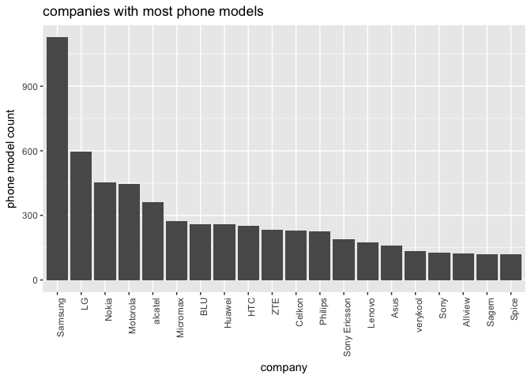

```r
# Q1
mobile %>% group_by(company ) %>% summarise(n = n()) %>%  arrange(desc(n))  %>% slice(1:20) -> data_1
data_1$company <- factor(data_1$company, levels = data_1$company)
ggplot(data = data_1) + geom_col(aes(x = company, y = n)) +
  theme(axis.text.x = element_text(angle = 90, hjust = 1)) +
  labs(title = 'companies with most phone models', y = 'phone model count')
```

> برای آنکه از به هم ریختن ترتیب شرکت ها جلوگیری کنیم سطوح factor آن را خودمان تعریف کرده ایم.

۲. نمودار زمانی طول عرض ضخامت و کیفیت دوربین گوشی ها را بکشید و به نمودار هر یک مدل خطی اضافه کنید.

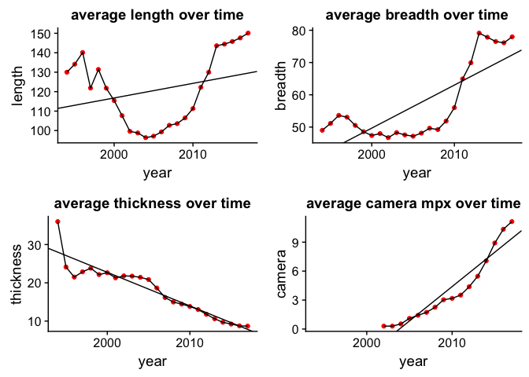

```r
# Q2_1
mobile %>% group_by(year) %>% summarise(length = mean(dim_length, na.rm = TRUE)) -> data_2_1
coef_2_1 <- coef(lm(length ~ year, data = data_2_1))
q2_1 <- ggplot(data = data_2_1, aes(x = year, y = length)) + geom_point(na.rm = TRUE, colour = 'red') + geom_line(na.rm = TRUE) +
  geom_abline(intercept = coef_2_1[1], slope = coef_2_1[2]) + labs(title = 'average length over time')


# Q2_2
mobile %>% group_by(year) %>% summarise(breadth = mean(dim_breadth, na.rm = TRUE)) -> data_2_2
coef_2_2 <- coef(lm(breadth ~ year, data = data_2_2))
q2_2 <- ggplot(data = data_2_2, aes(x = year, y = breadth)) + geom_point(na.rm = TRUE, colour = 'red') + geom_line(na.rm = TRUE) +
  geom_abline(intercept = coef_2_2[1], slope = coef_2_2[2]) + labs(title = 'average breadth over time')

#Q2_3
mobile %>% group_by(year) %>% summarise(thickness = mean(dim_thickness, na.rm = TRUE)) -> data_2_3
coef_2_3 <- coef(lm(thickness ~ year, data = data_2_3))
q2_3 <- ggplot(data = data_2_3, aes(x = year, y = thickness)) + geom_point(na.rm = TRUE, colour = 'red') + geom_line(na.rm = TRUE) +
  geom_abline(intercept = coef_2_3[1], slope = coef_2_3[2]) + labs(title = 'average thickness over time')

#Q2_4
mobile %>% group_by(year) %>% summarise(camera = mean(cam_px, na.rm = TRUE)) -> data_2_4
coef_2_4 <- coef(lm(camera ~ year, data = data_2_4))
q2_4 <- ggplot(data = data_2_4, aes(x = year, y = camera)) + geom_point(na.rm = TRUE, colour = 'red') + geom_line(na.rm = TRUE) +
  geom_abline(intercept = coef_2_4[1], slope = coef_2_4[2]) + labs(title = 'average camera mpx over time')

# Q2 SUMMARIZATION
library(cowplot)
plot_grid(q2_1, q2_2, q2_3, q2_4)
```

> برای تولید مدل خطی از تابع coef و تابع مدل خطی lm استفاده کرده ایم. ضرایب خروجی را به کمک تابع geom_abline به صورت یک خط رسم کرده ایم.

۳. نمودار ستونی متوسط قیمت گوشی بر حسب تعداد سیم کارت و دسترسی به LTE را رسم نمایید.

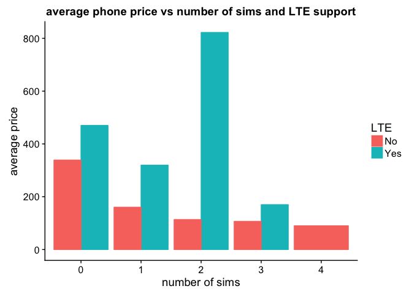

```r
#Q3
mobile %>% group_by(LTE, sim_no) %>% summarise(value = mean(price, na.rm = TRUE)) -> data_3
data_3$sim_no <- factor(data_3$sim_no)
ggplot(data = data_3) +
  geom_col(aes(y = value, x = sim_no, color = LTE, fill = LTE), na.rm = TRUE, position = 'dodge') +
  labs(title = 'average phone price vs number of sims and LTE support', x = 'number of sims', y = 'average price')
```

۴. نمودار جعبه ایی ضحامت گوشی هایی که در سال ۲۰۱۷ معرفی شده اند را برحسب اینکه کمیت جک هدفون رسم نمایید

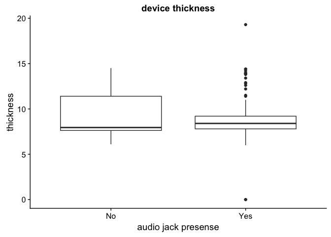

```r
#Q4
mobile %>% filter(as.integer(year) == 2017) -> data_4
ggplot(data = data_4) + geom_boxplot(aes(y = dim_thickness, x = audio_jack), na.rm = TRUE) +
  labs(title = 'device thickness', y = 'thickness', x = 'audio jack presense')
```

>

> ۵. مفهوم ppi را در گوشی های موبایل محاسبه و هیستوگرام آن را رسم نمایید. همچنین نمودار سالانه متوسط این کمیت را بکشید. کدام گوشی بیشترین ppi را دارد؟

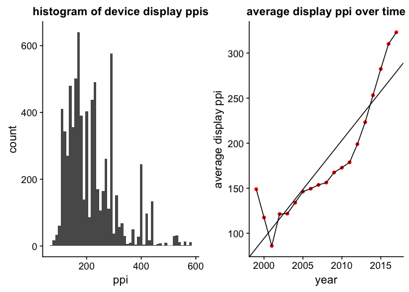

```r
#Q5_1
mobile %>% mutate(ppi = sqrt(px_row ^ 2 + px_col ^ 2) / display_size) %>% filter(ppi < 700) -> data_5_1
plot_5_1 <- ggplot(data = data_5_1) + geom_histogram(aes(x = ppi), binwidth = 10, na.rm = TRUE) +
  labs(title = 'histogram of device display ppis')

#Q5_2
data_5_1 %>% group_by(year) %>% summarise(mean_ppi = mean(ppi, na.rm = TRUE)) -> data_5_2
coef_5_2 <- coef(lm(mean_ppi~year, data = data_5_2))

plot_5_2 <- ggplot(data = data_5_2, aes(x = year, y = mean_ppi)) + geom_point(colour = 'red', na.rm = TRUE) +
  geom_line(na.rm = TRUE) +
  geom_abline(intercept = coef_5_2[1], slope = coef_5_2[2]) +
  labs(title = 'average display ppi over time', y = 'average display ppi')

plot_grid(plot_5_1, plot_5_2)
```

۶. در گذشته به بعضی از مدل های گوشی نوکیا **گوشکوب** گفته می شد. سعی کنید برای این مفهوم کمیتی مناسب تعریف کنید . ده گوشکوب برتر را پیدا کرده و نمودار گوشکوبیت آن را رسم نمایید.

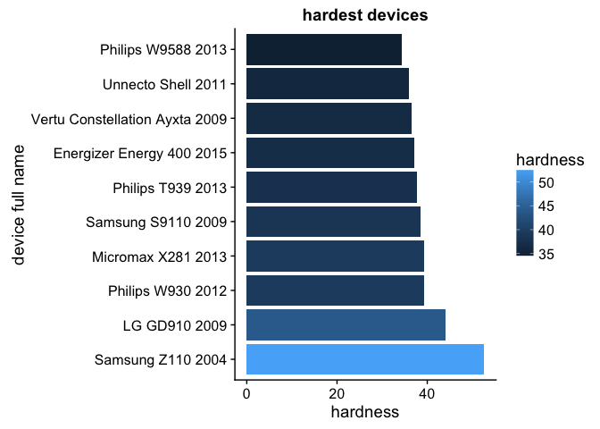

```r
mobile %>% filter(year < 2010 | display_size > 2) %>%
  filter(display_size < 7) %>%
  mutate(volume = dim_breadth * dim_length * dim_thickness) %>%
  mutate(hardness = 1000 * weight / volume * dim_thickness) %>% filter(hardness < Inf) %>%
  select(company, device, year, hardness) %>% arrange(desc(hardness)) %>% slice(1:10) %>%
  mutate(full_name = paste(company, device, year)) %>% select(full_name, hardness) -> data_6

data_6$full_name <- factor(data_6$full_name, levels = data_6$full_name)
ggplot(data = data_6) + geom_col(aes(x = full_name, y = hardness, fill = hardness)) + coord_flip() +
  labs(title = 'hardest devices', x = 'device full name')
```

> از دانسته های مکانیکی می دانیم که سختی یک جسم (که در این سوال مورد نظر است) ربطی به چگالی آن جسم یا ابعادش (تنها فاکتور های فیزیکی در دسترس از اشیا) ندارد. اما با فرض اینکه تلفن های همراه از پلی کربنات، شیشه، آلومینیوم و سیلیکون تشکیل شده باشند می توان با استفاده از چگالی آنها و قطرشان (قطر مقطعی که به عنوان گوشکوب استفاده می شود :دی) میزان سختی آنها را تخمین زد. به این منظور برای به دست آوردن تخمینی از سختی، چگالی هر گوشی را ضربدر قطر آن کرده ایم و آن را به عنوان فاکتوری از سختی در نظر گرفته ایم. لازم به ذکر است که در این سوال برای آنکه تنها تلفن های همراه مورد بررسی قرار بگیرند این شرط را گذاشته ایم که اندازه ی صفحه ی نمایش زیر ۷ اینچ باشد و در صورتی که دستگاه بعد از سال ۲۰۱۰ تولید شده، اندازه بالای ۲ اینچ هم باشد (خارج کردن ساعت های هوشمند!).

۷. آیا تلفن همراهی وجود دارد که در آب غرق نشود؟ اگر جواب بله هست تمام گوشی های که این خاصیت را دارند بیابید. با کشیدن یک نمودار به این سوال پاسخ دهید.

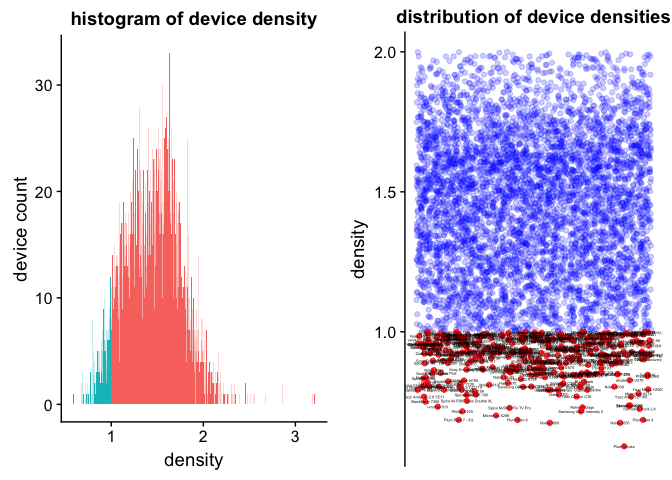

```r
#Q7

# mobile %>% mutate(volume = dim_breadth * dim_length * dim_thickness) %>% mutate(density = 1000 * weight/volume) %>%
#   filter((year <= 2010 | year > 2010 & display_size > 2) & display_size < 7) %>% arrange(density) %>% View()

mobile %>% mutate(volume = dim_breadth * dim_length * dim_thickness) %>% mutate(dent = 1000 * weight/volume) %>%
  filter((year <= 2010 | year > 2010 & display_size > 2) & display_size < 7) -> data_7

plot_7_1 <- ggplot(data = data_7) +
  geom_histogram(aes(x = dent, fill = ifelse(dent < 1, 'red', 'blue')), bins = 1000, na.rm = TRUE) +
  guides(fill = FALSE) + labs(title = 'histogram of device density', x = 'density', y = 'device count')

#Q7_2
data_7 %>% mutate(x_pos = 0, full_name = paste(company, device)) %>% filter(dent < 2) -> data_7
data_7$x_pos <- jitter(data_7$x_pos)

plot_7_2 <- ggplot() + geom_point(data = data_7[which(data_7$dent >= 1),], colour = 'blue', alpha = 0.2, aes(x = x_pos, y = dent)) +
  geom_point(data = data_7[which(data_7$dent < 1),], colour = 'red', alpha = 0.8, aes(x = x_pos, y = dent)) +
  geom_text(data = data_7[which(data_7$dent < 1),], aes(x = x_pos, y = dent, label = full_name), size = 1) +
  theme(axis.line.x = element_blank(), axis.text.x = element_blank(), axis.ticks.x = element_blank(), axis.title.x = element_blank()) +
  labs(y = 'density', title = 'distribution of device densities')

plot_grid(plot_7_1, plot_7_2)
```

> در این سوال هم با اعمال شرایطی تنها گوشی های موبایل را مورد بررسی قرار داده ایم. نمودار سمت چپ نمودار توزیع چگالی در نمونه ی در دسترس را نشان می دهد و بخش آبی رنگ بخشی است که روی آب خواهد ایستاد. در نمودار سمت راست هر نقطه معادل یک دستگاه با چگالی زیر ۲ است و نقاط قرمز رنگ دستگاه هایی هستند که روی آب خواهند ماند. نام هر یک از این نقاط روی آن نوشته شده است.

۸. نمودار پراکنش حجم ذخیره سازی باطری و وزن را رسم نمایید. میزان همبستگی بین این دو کمیت را محاسبه کنید.

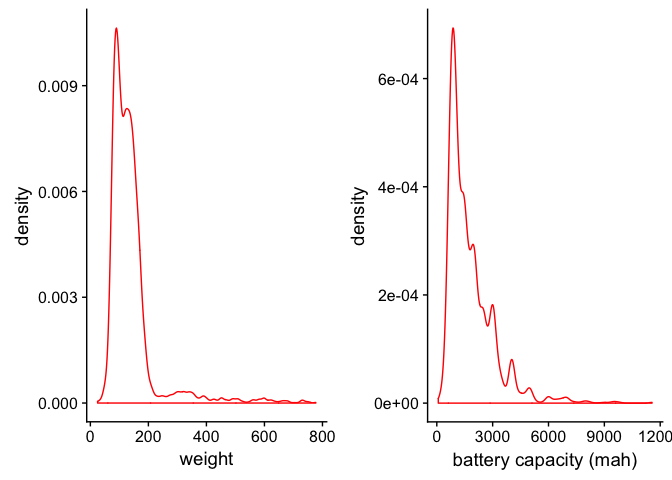

```r
#Q8_1
mobile %>% .[complete.cases(.$weight), ] %>% select(weight) %>% filter(weight < 800) -> data_8_1
plot_8_1 <- ggplot(data = data_8_1) + geom_density(aes(x = weight), colour = 'red')

#Q8_2
mobile %>% .[complete.cases(.$battery_mah), ] %>% select(battery_mah) -> data_8_2
plot_8_2 <- ggplot(data = data_8_2) + geom_density(aes(x = battery_mah), colour = 'red') + labs(x = 'battery capacity (mah)')

plot_grid(plot_8_1, plot_8_2)
```

```r
#Q8_3
mobile %>% .[complete.cases(.$battery_mah),] %>% .[complete.cases(.$weight),] %>% select(battery_mah, weight) -> data_8_3
cor(data_8_3[1], data_8_3[2]) # 0.8086273
```

```
##                weight
## battery_mah 0.8086273
```

> لازم به توجه است در این نمودار برای ترسیم بهتر از وزن های بالای ۸۰۰ گرم که داده ی بسیار کمی داشتند صرف نظر شده است.

۹. قیمت پرچمداران یک برند خاص مثلا سامسونگ را بیابید و نمودار قیمت زمان و نام مدل را رسم نمایید.

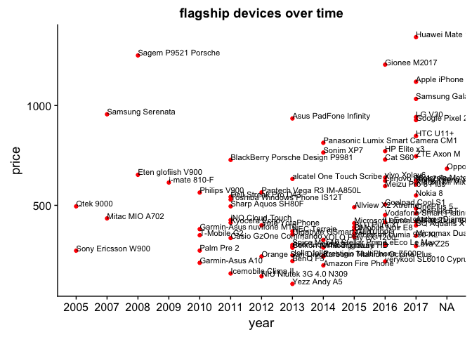

```r
#Q9_ESHTEBAHI
mobile %>% filter(price < 1500 & display_size < 7 & display_size > 2) %>% group_by(company) %>%
  filter(price == max(price)) %>% mutate(full_name = paste(company, device)) %>% arrange(year) -> data_9

data_9$price <- jitter(data_9$price, factor = 50)

data_9$year <- factor(data_9$year, levels = data_9$year %>% unique())
ggplot(data = data_9, aes(x = year, y = price)) + geom_point(colour = 'red') +
  geom_text(aes(label = full_name), hjust=0, vjust=0, size = 3) + labs(title = 'flagship devices over time')
```

> لازم به ذکر است این نمودار خواسته ی سوال نیست! در بخش بعدی به دو روش دقیق و دقیق تر به خواسته ی اصلی پاسخ گفته شده است. این نمودار آخرین پرچمداران هر شرکت را نشان می دهد. دقت می کنیم برخی شرکت ها مانند توشیبا یا سونی اریکسون مدت هاست موبایل یا پرچمداری تولید نکرده اند.

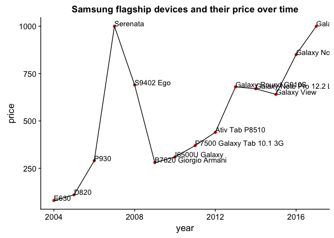

```r
#Q9_solution_1
mobile %>% filter(company == 'Samsung') %>% group_by(year) %>% top_n(1, price) %>% slice(1) -> data_9_1
ggplot(data = data_9_1, aes(x = year, y= price)) + geom_point(na.rm = TRUE, colour = 'red') +
  geom_line(na.rm = TRUE) + geom_text(aes(label = device), hjust=0, vjust=0, na.rm = TRUE) +
  labs(title = 'Samsung flagship devices and their price over time')
```

> در این روش برای به دست آوردن پرچمداران هر ساله ی سامسونگ، تلفن همراه با بیشترین قیمت را در هر سال به دست آورده ایم.

```r
#Q9_solution_2
mobile %>% filter(company == 'Samsung' & (year <= 2010 | year > 2010 & display_size > 2) & display_size < 7) %>%
  group_by(year) %>% summarise(avg = mean(price, na.rm = TRUE), var = sd(price, na.rm = TRUE)) %>%
  .[complete.cases(.$year,.$avg,.$var),] -> Q9_stats
min_var_coef <- 1
max_var_coef <- 7
mobile %>% filter(company == 'Samsung' & (year <= 2010 | year > 2010 & display_size > 2) & display_size < 7) %>%
  full_join(Q9_stats) %>% filter(price > (avg + min_var_coef * var) & price < (avg + max_var_coef * var)) %>%
  group_by(year) %>%  top_n(1, price) %>% slice(1) -> data_9_2
```

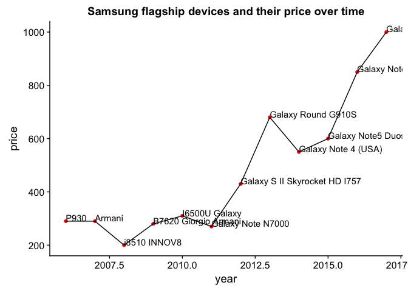

```r
ggplot(data = data_9_2, aes(x = year, y= price)) + geom_point(colour = 'red') + geom_line() +
  geom_text(aes(label = device), hjust=0, vjust=0) +
  labs(title = 'Samsung flagship devices and their price over time')
```

> در این روش برای به دست آوردن پرچمدار هر ساله ی سامسونگ تلفنی انتخاب شده که قیمت آن از میانگین به علاوه ی واریانس قیمت گوشی های سامسونگ در آن سال بیشتر و از میانگین به علاوه ی ۷ برابر واریانس قیمت کمتر باشد. لازم به ذکر است این اعداد با مقایسه ی نتایج با نتایچ واقعی و با آزمون و خطا به دست آمده اند. در صورتی که چند گوشی در این شروط در یک سال صدق می کردند، گوشی با بالاترین قیمت انتخاب شده است.در صورتی که بیشتر از یک گوشی در این حالت نیز وجود داشت اولین آنها گزارش شده.

۱۰. سه نمودار جالب رسم کنید و توضیح دهید چرا از نظر شما جالب است؟

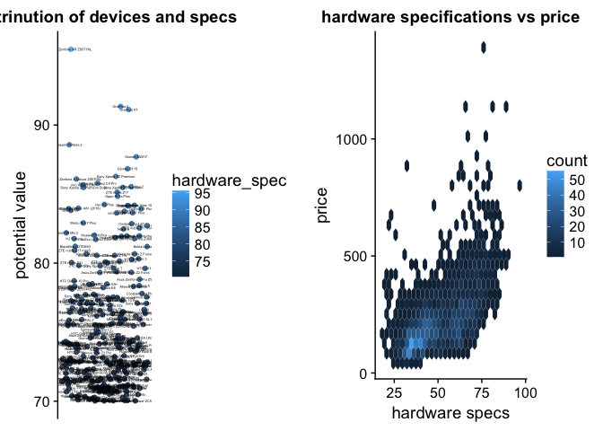

```r
#Q10_1

# best phones to buy each year
# high ppi # large ram # large battery * battrty generation # more thinness # camera px + selfie px

mean_ppi <- mobile %>% mutate(ppi = sqrt(px_row ^ 2 + px_col ^ 2) / display_size) %>% summarise(mean(ppi, na.rm = TRUE)) %>% as.numeric()
mean_ram <- mobile %>% summarise(mean(ram, na.rm = TRUE)) %>% as.numeric()
mean_bat <- mobile %>% summarise(mean(battery_mah, na.rm = TRUE)) %>% as.numeric()
mean_btv <- mobile %>% summarise(mean(bt_v, na.rm = TRUE)) %>% as.numeric()
mean_pri_cam <- mobile %>% summarise(mean(cam_px, na.rm = TRUE)) %>% as.numeric()
mean_sec_cam <- mobile %>% summarise(mean(sel_px, na.rm = TRUE)) %>% as.numeric()
mean_thinness <- mobile %>% summarise(mean(dim_thickness, na.rm = TRUE)) %>% as.numeric()
mean_thinness <- 1 / mean_thinness
mean_price <- mobile %>% summarise(mean(price, na.rm = TRUE)) %>% as.numeric()
mean_price <- 1 / mean_price
mean_weight <- mobile %>% summarise(mean(weight, na.rm = TRUE)) %>% as.numeric()
mean_weight <- 1 / mean_weight

f <- 5 # importance factor
min_spec <- 70

mobile %>% .[complete.cases(.$price), ] %>%  mutate(ppi = sqrt(px_row ^ 2 + px_col ^ 2) / display_size) %>%
  mutate(hardware_spec = ppi/mean_ppi*f + ram/mean_ram*f + battery_mah/mean_bat*f + bt_v/mean_btv + cam_px/mean_pri_cam*f +
           sel_px/mean_sec_cam + 1/dim_thickness/mean_thinness*f + 1/weight/mean_weight*f +
           (LTE == 'Yes')*f + (gps == 'Yes') + (radio == 'Yes') + (nfc == 'Yes') + (wlan == 'Yes') + (audio_jack == 'Yes')) %>%
  arrange(desc(hardware_spec)) -> data_10_1

data_10_1 %>% mutate(x_pos = 0, full_name = paste(company, device)) -> data_10_1
data_10_1$x_pos <- jitter(data_10_1$x_pos)

 ggplot(data = (data_10_1 %>% filter(hardware_spec > min_spec)), aes(x = x_pos, y = hardware_spec)) + geom_point(alpha = 0.8, aes(color = hardware_spec)) +
  geom_text(aes(label = full_name), size = 1) +
  theme(axis.line.x = element_blank(),
        axis.text.x = element_blank(),
        axis.ticks.x = element_blank(),
        axis.title.x = element_blank()) +
  labs(y = 'potential value', title = 'distrinution of devices and specs') -> plot_10_1_1

data_10_1 %>% filter(price < 1500) %>% ggplot(.) +
  geom_hex(aes(x = hardware_spec, y = price, color = price/hardware_spec)) +
  labs(x = 'hardware specs', title = 'hardware specifications vs price') -> plot_10_1_2

plot_grid(plot_10_1_1, plot_10_1_2)
```

>

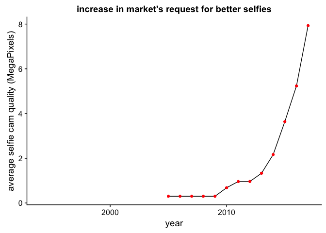

```r
# Q10_2
# incrase in peoples interest in taking selfies
mobile %>% group_by(year) %>% summarise(mean_selfie = mean(sel_px, na.rm = TRUE)) %>%
  ggplot(., aes(x = year, y = mean_selfie)) + geom_line(na.rm = TRUE) + geom_point(na.rm = TRUE, colour = 'red') +
  labs(y = 'average selfie cam quality (MegaPixels)', title = 'increase in market\'s request for better selfies')
```

> در این بخش با مشاهده ی نحوه ی رشد قدرت دوربین سلفی تلفن های هوشمند طی زمان افزایش اقبال مردم و بازار به دوربین سلفی و گرفتن عکس سلفی را طی چند سال اخیر بررسی کرده ایم. مشاهده می شود که علاقه ی مردم به عکاسی از خودشان رشد نمایی داشته است!

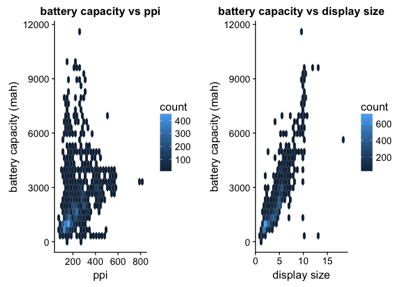

```r
# Q10_3
# battery size vs ppi and display size
mobile %>% mutate(ppi = sqrt(px_row ^ 2 + px_col ^ 2) / display_size) %>% ggplot(., aes(x = ppi, y = battery_mah)) +
  geom_hex(na.rm = TRUE) +
  labs(y = 'battery capacity (mah)', title = 'battery capacity vs ppi') -> plot_10_3_1

mobile %>% mutate(ppi = sqrt(px_row ^ 2 + px_col ^ 2) / display_size) %>% ggplot(., aes(x = display_size, y = battery_mah)) +
  geom_hex(na.rm = TRUE) +
  labs(y = 'battery capacity (mah)', title = 'battery capacity vs display size', x = 'display size') -> plot_10_3_2

plot_grid(plot_10_3_1, plot_10_3_2)
```

```r
library(magrittr)
mobile %>% mutate(ppi = sqrt(px_row ^ 2 + px_col ^ 2) / display_size) %>%
  .[complete.cases(.$battery_mah, .$ppi),] %$% cor(.$battery_mah, .$ppi) # 0.4474414
```

```
## [1] 0.4474414
```

```r
mobile %>% .[complete.cases(.$battery_mah, .$display_size),] %$%
  cor(.$battery_mah, .$display_size) # 0.8855491
```

```
## [1] 0.8855491
```

> در این بخش با استفاده از نمودار های حرارتی میزان همبستگی اندازه ی صفحه ی نمایش و دقت آن به میزان باتری قرار گرفته در دستگاه مورد بررسی قرار گرفته است. دقت می شود که همبستگی اول خیلی مشهود تر از همبستگی دوم است.

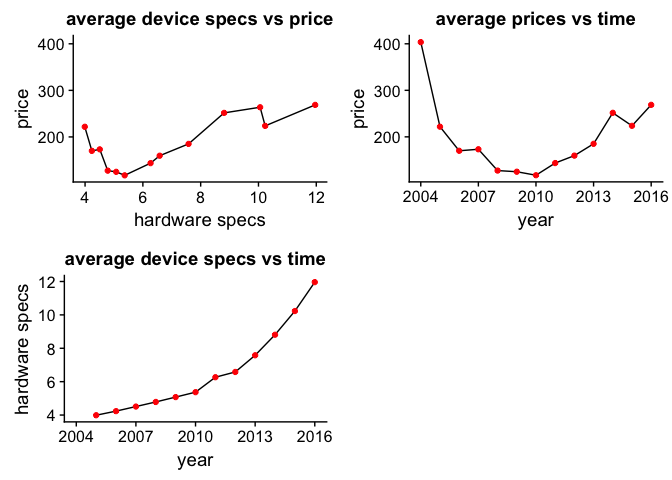

```r
# Q10_4
# hardware price changes over time
mobile %>% mutate(ppi = sqrt(px_row ^ 2 + px_col ^ 2) / display_size) %>%  group_by(year) %>%
  summarise(hw_spec = (mean(cam_px, na.rm = T)/mean_pri_cam + mean(sel_px, na.rm = T)/mean_sec_cam +
                       mean(battery_mah, na.rm = T)/mean_bat + mean(ram, na.rm = T)/mean_ram +
                       mean(bt_v, na.rm = T)/mean_btv + mean(ppi, na.rm = T)/mean_ppi) +
                       1/mean(dim_thickness, na.rm = T)/mean_thinness + 1/mean(weight, na.rm = T)/mean_weight,
            price = mean(price, na.rm = TRUE)) %>% filter(price < 1500) -> data_10_3
data_10_3 %>% ggplot(., aes(y = price, x = hw_spec)) + geom_line(na.rm = T) + geom_point(na.rm = T, colour = 'red') +
  labs(title = 'average device specs vs price', x = 'hardware specs', y = 'price') -> plot_10_3_1
data_10_3 %>% ggplot(., aes(y = price, x = year)) + geom_line(na.rm = T) + geom_point(na.rm = T, colour = 'red') +
  labs(title = 'average prices vs time') -> plot_10_3_2
data_10_3 %>% ggplot(., aes(y = hw_spec, x = year)) + geom_line(na.rm = T) + geom_point(na.rm = T, colour = 'red') +
  labs(title = 'average device specs vs time', y = 'hardware specs') -> plot_10_3_3

plot_grid(plot_10_3_1, plot_10_3_2, plot_10_3_3)
```

>

در این بخش با محاسبه ی فاکتور قدرت سخت افزار مانند بخش اول سوال ۱۰ به بررسی تغییرات سه متغیر قدرت سخت افزار، زمان و قیمت تمام شده در طول زمان می پردازیم. مشاهده می شود که قدرت متوسط سخت افزار در طول زمان رشد نمایی داشته است. قیمت تمام شده ی نهایی سخت افزار طی زمان و با پیشرفت تکنولوژی و تا قبل از ظهور تلفن های هوشمند با قطعات پیشرفته کاهش یافته و پس از آن با شیب کمتری افزایش یافته است. مشاهده می شود که قدرت متوسط سخت افزار طی زمان افزایش یافته است!

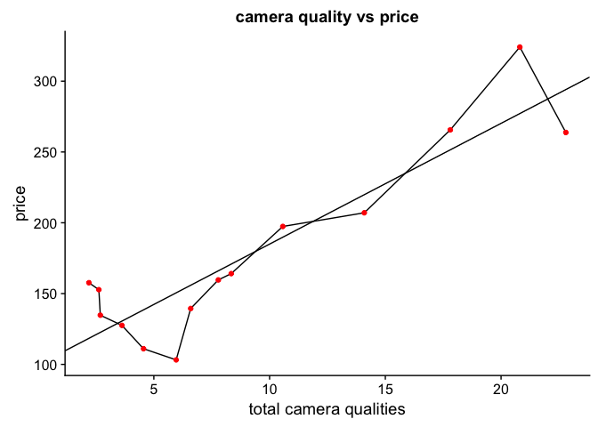

```r
# Q10_5
# camera vs price

mobile %>% filter(price < 1500) %>% mutate(cam_tot_px = cam_px + sel_px) %>% group_by(year) %>%
  summarise(cam = mean(cam_tot_px, na.rm = T), price = mean(price, na.rm = T)) -> data_10_5
coef_10_5 <- coef(lm(price~cam, data = data_10_5))
data_10_5 %>%
  ggplot(., aes(x = cam, y = price)) + geom_line(na.rm = T) + geom_point(na.rm = T, colour = 'red') +
  labs(title = 'camera quality vs price', x = 'total camera qualities') + geom_abline(intercept = coef_10_5[1], slope = coef_10_5[2])
```

> در این بخش سعی شده تاثیر کیفیت دوربیت گوشی بر قیمت آن مورد بررسی قرار بگیرد. به این منظور معیاری در نظر گرفته شده که برابر جمع کیفیت دوربین های هر گوشی برای آن گوشی است.مشاهده می شود که با افزایش کیفیت دوربین گوشی، قیمت آن به صورت مشهودی افزایش می یابد! این افزایش قیمت به نظر خطی می آید.